# Лабораторная работа №16

Имитационное моделирование

Серёгина Ирина Андреевна

Российский университет дружбы народов, Москва, Россия

24 мяа 2025

## Цель работы

Реализовать с помощью gpss модель двух стратегий обслуживания и оценить оптимальные параметры.

## Задание

1. Реализовать с помощью gpss модель с двумя очередями
2. Реализовать с помощью gpss модель с одной очередью
3. Изменить модели, чтобы определить оптимальное число пропускных пунктов.

## Выполнение лабораторной работы

На пограничном контрольно-пропускном пункте транспорта имеются 2 пункта пропуска. Интервалы времени между поступлением автомобилей имеют экспоненциальное распределение со средним значением *μ*. Время прохождения автомобилями пограничного контроля имеет равномерное распределение на интервале [*a*, *b*]. Предлагается две стратегии обслуживания прибывающих автомобилей:

1. автомобили образуют две очереди и обслуживаются соответствующими пунктами пропуска;
2. автомобили образуют одну общую очередь и обслуживаются освободившимся пунктом пропуска. Исходные данные: *μ* = 1, 75 мин, *a* = 1 мин, *b* = 7 мин.

## Выполнение лабораторной работы

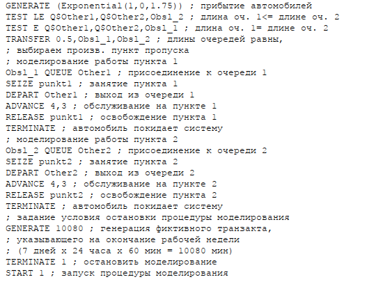

Модель первой стратегии обслуживания

## Выполнение лабораторной работы

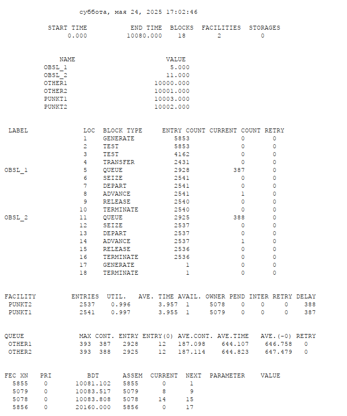

Отчёт модели первой стратегии обслуживания

## Выполнение лабораторной работы

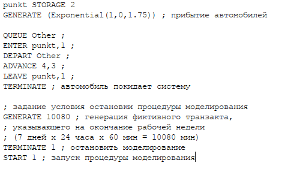

Модель второй стратегии обслуживания

## Выполнение лабораторной работы

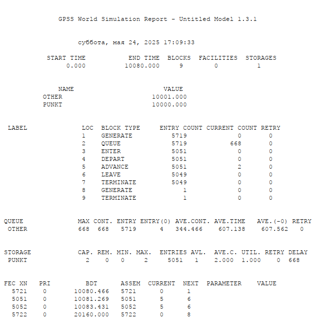

Отчёт модели второй стратегии обслуживания

## Выполнение лабораторной работы

Сравнение стратегий

| Показатель | стратегия 1 |  |  | стратегия 2 |
| --- | --- | --- | --- | --- |
|  | пункт 1 | пункт 2 | в целом |  |
| Поступило автомобилей | 2928 | 2925 | 5853 | 5719 |
| Обслужено автомобилей | 2540 | 2536 | 5076 | 5049 |
| Коэффициент загрузки | 0,997 | 0,996 | 0,9965 | 1 |
| Максимальная длина очереди | 393 | 393 | 786 | 668 |
| Средняя длина очереди | 187,098 | 187,114 | 374,212 | 344,466 |
| Среднее время ожидания | 644,107 | 644,823 | 644,465 | 607,138 |

## Выполнение лабораторной работы

Далее необходимо изменив модели, определить оптимальное число пропускных пунктов (от 1 до 4) для каждой стратегии при условии, что: – коэффициент загрузки пропускных пунктов принадлежит интервалу [0, 5; 0, 95]; – среднее число автомобилей, одновременно находящихся на контрольно -пропускном пункте, не должно превышать 3; – среднее время ожидания обслуживания не должно превышать 4 мин

## Выполнение лабораторной работы

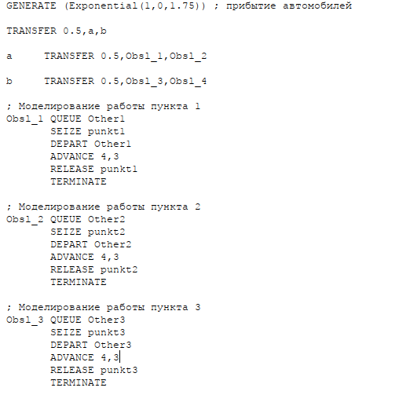

Модель первой стратегии обслуживания с 4 КПП

## Выполнение лабораторной работы

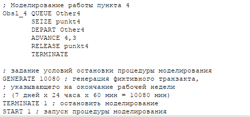

Модель первой стратегии обслуживания с 4 КПП

## Выполнение лабораторной работы

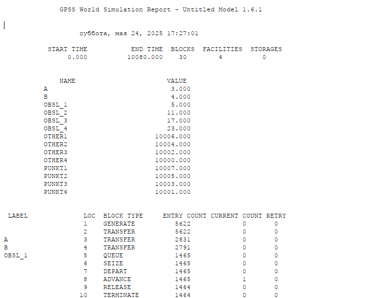

Отчёт модели первой стратегии обслуживания с 4 КПП

## Выполнение лабораторной работы

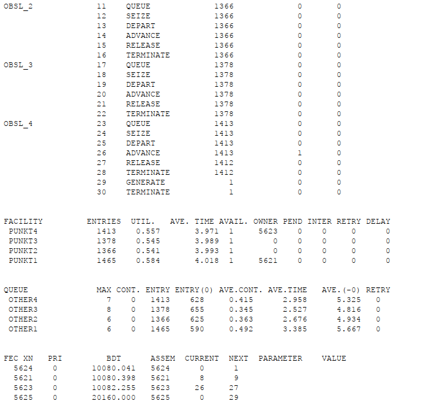

Отчёт модели первой стратегии обслуживания с 4 КПП

## Выполнение лабораторной работы

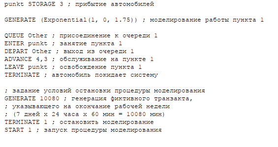

Модель второй стратегии обслуживания с 3 КПП

## Выполнение лабораторной работы

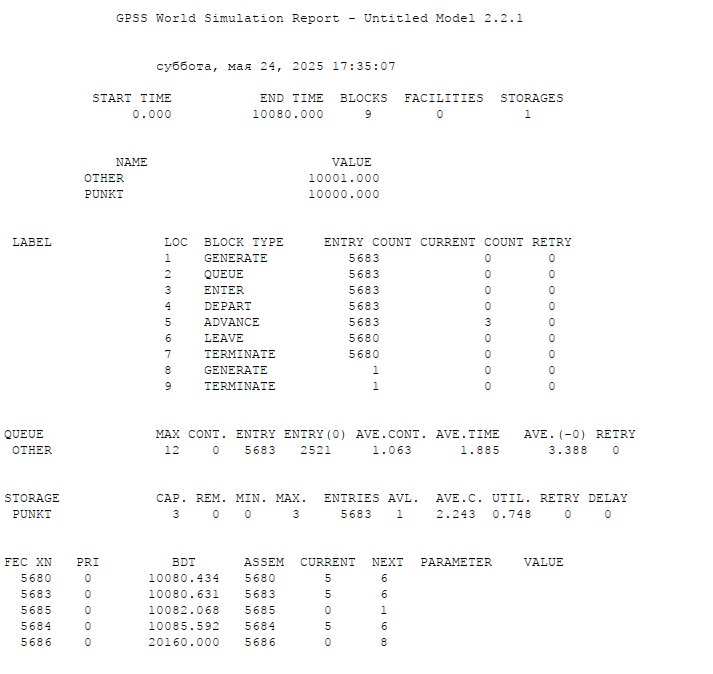

Отчёт модели второй стратегии обслуживания с 3 КПП

## Выводы

Я реализовала с помощью gpss модель двух стратегий обслуживания и оценить оптимальные параметры.

Спасибо за внимание!